# Coursera Prediction Assignment Writeup

Alexey Maranda

14 February 2017

One thing that people regularly do is quantify how much of a particular activity they do, but they rarely quantify how well they do it. In this project, your goal will be to use data from accelerometers on the belt, forearm, arm, and dumbell of 6 participants. The goal of your project is to predict the manner in which they did the exercise.

## Synopsis

Using devices such as Jawbone Up, Nike FuelBand, and Fitbit it is now possible to collect a large amount of data about personal activity relatively inexpensively. These type of devices are part of the quantified self movement – a group of enthusiasts who take measurements about themselves regularly to improve their health, to find patterns in their behavior, or because they are tech geeks. One thing that people regularly do is quantify how much of a particular activity they do, but they rarely quantify how well they do it. In this project, your goal will be to use data from accelerometers on the belt, forearm, arm, and dumbell of 6 participants. They were asked to perform barbell lifts correctly and incorrectly in 5 different ways. More information is available from the website here: http://groupware.les.inf.puc-rio.br/har (see the section on the Weight Lifting Exercise Dataset).

### Libraries

```r
library(caret)
```

```r
library(corrplot)
```

## Data Preprocessing

### Getting Data

```r
training_dat = read.csv("https://d396qusza40orc.cloudfront.net/predmachlearn/pml-training.csv" ,
                        na.strings = c("NA", ""))
test_dat = read.csv("https://d396qusza40orc.cloudfront.net/predmachlearn/pml-testing.csv",
                    na.strings = c("NA", ""))

# Exploring Data Analysis
dim(training_dat) ; dim(test_dat)
```

```
## [1] 19622   160
```

```
## [1]  20 160
```

```r
table(training_dat$classe)
```

```
##
##    A    B    C    D    E
## 5580 3797 3422 3216 3607
```

The training data set contains 19622 observations and 160 variables

### Cleaning the data and dimension reduction

In this step, we will clean the data and get rid of observations with missing values as well as some meaningless variables. There are further unnecessary columns that can be removed. The column X contains the row numbers. The column user_name contains the name of the user. Of course, these variables cannot predictors for the type of exercise. Furthermore, the three columns containing time stamps ( raw_timestamp_part_1 , raw_timestamp_part_2 , and cvtd_timestamp ) will not be used. The factors new_window and num_window are not related to sensor data. They will be removed too.

```r
# Remove Near Zero Values columns
training_subdat <- training_dat[ , names(training_dat)[!nearZeroVar(training_dat, saveMetrics=TRUE)$nzv]]

# Remove columns with NA
colsNAs <- colMeans(is.na(training_subdat))
indx <- !colsNAs
training_subdat <- training_subdat[indx]
str(training_subdat)

# remove columns which aren't predictors : x ( unique row ID ) ,
# user_name , raw_timestamp_part_1 , raw_timestamp_part_2 , cvtd_timestamp, num_window
training_subdat <- training_subdat[, -c(1:6)]
dim(training_subdat)
```

[output not shown]

As we can see our data now has only 53 columns for modeling.

### Split data to testing and training sets

Now we split the training set into two for cross validation purposes. Use the caret to randomly subsample 75% for training set and 25% to testing set.

```r
inTrain = createDataPartition(training_subdat$classe, p = 0.75)[[1]]
training = training_subdat[inTrain, ]
testing = training_subdat[-inTrain, ]
dim(training) ; dim(testing)
```

[output not shown]

Also we should remove those variable which has high correlation. A good set of features is when they are highly uncorrelated (orthogonal) each others.

```r
# remove "classe" column to build correlation matrix
descrCorr <- cor(training[, 1:52])

# get correlation matrix whit the pair-wise absolute correlation cutoff more 90%
highCorr <- findCorrelation(descrCorr, 0.90)

# delete correlated columns from training and test sets
training <- training[, -highCorr]
testing <- testing[, -highCorr]
```

## Prediction modeling

```r
# set seed
set.seed(12345)

# Setting the parameters for model preprocessing
fitControl <- trainControl(method = "cv",
                           number = 5,
                           repeats = 3 ,
                           preProcOptions="pca")

# training models
fit_rf <- train(classe ~ ., method = "rf", data = training , trControl = fitControl )
fit_lda <- train(classe ~ ., method = "lda",  data = training)
fit_boosted <- train(classe ~ ., method = "gbm",  data = training , trControl = fitControl)
fit_nb <- train(classe ~ ., method = "nb",  data = training , trControl = fitControl)

# test models
prediction_rf <- predict(fit_rf, testing)
prediction_boosted <- predict(fit_boosted, testing)
prediction_lda <- predict(fit_lda, testing)
prediction_nb <- predict(fit_nb, testing)
```

Note training Random Forest took about 15 minutes on my computer (Intel Core I5 3,2 Gh, 8 Gb , Win 7). For better understanding our data we predict and visualise the most importance variebles from the test dataset using Random Forest model:

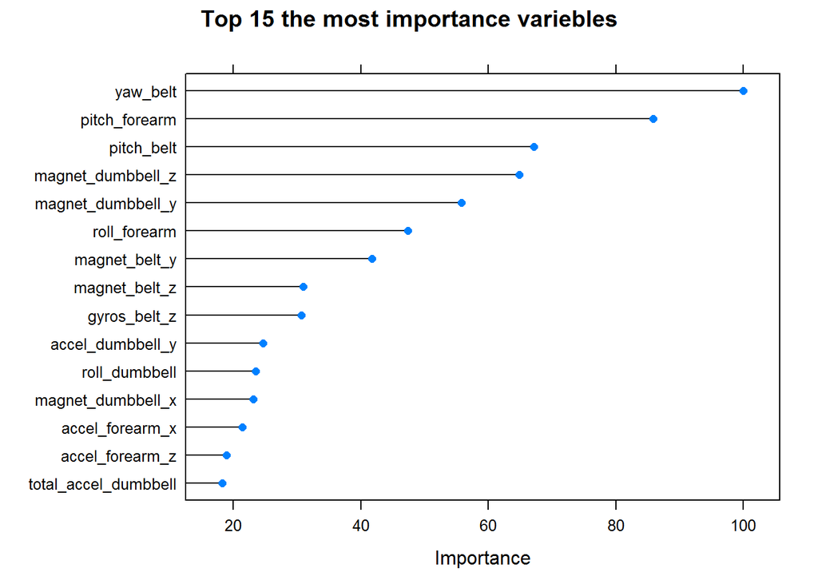

```r
plot(varImp(fit_rf) , top = 15 , main="Top 15 the most importance variebles")
```

To compare models each other we make table with Accuracy for each model:

```r
# Measuring Models Accuracy

Accuracy <- c(confusionMatrix(prediction_rf, testing$classe)$overall[1],
              confusionMatrix(prediction_boosted, testing$classe)$overall[1],
              confusionMatrix(prediction_lda, testing$classe)$overall[1],
              confusionMatrix(prediction_nb, testing$classe)$overall[1])
ModelType <- c("Random Forest","Boosted Tree","Linear Discriminant","Naive Bayes")
PerformanceTable <- data.frame(ModelType,Accuracy)
print(PerformanceTable)
```

```
##             ModelType  Accuracy
## 1       Random Forest 0.9953100
## 2        Boosted Tree 0.9567700
## 3 Linear Discriminant 0.6710848
## 4         Naive Bayes 0.7575449
```

```r
# Out-of Sample Accuracy for Random Forest
confusionMatrix(prediction_rf, testing$classe)
```

```
## Confusion Matrix and Statistics
##
##           Reference
## Prediction    A    B    C    D    E
##          A 1394    4    0    0    0
##          B    1  944    5    0    0
##          C    0    1  847    7    0
##          D    0    0    3  795    0
##          E    0    0    0    2  901
##
## Overall Statistics
##
##                Accuracy : 0.9953
##                  95% CI : (0.993, 0.997)
##     No Information Rate : 0.2845
##     P-Value [Acc > NIR] : < 2.2e-16
##
##                   Kappa : 0.9941
##  Mcnemar's Test P-Value : NA
##
## Statistics by Class:
##
##                      Class: A Class: B Class: C Class: D Class: E
## Sensitivity            0.9993   0.9947   0.9906   0.9888   1.0000
## Specificity            0.9989   0.9985   0.9980   0.9993   0.9995
## Pos Pred Value         0.9971   0.9937   0.9906   0.9962   0.9978
## Neg Pred Value         0.9997   0.9987   0.9980   0.9978   1.0000
## Prevalence             0.2845   0.1935   0.1743   0.1639   0.1837
## Detection Rate         0.2843   0.1925   0.1727   0.1621   0.1837
## Detection Prevalence   0.2851   0.1937   0.1743   0.1627   0.1841
## Balanced Accuracy      0.9991   0.9966   0.9943   0.9940   0.9998
```

As we see Random Forest algorithm shows the best Accuracy more 99% , will use it for making prediction our unknown data.

## Applying the selected Model to the Test Data

```r
predictions <- predict(fit_rf, test_dat)
# show prediction results
predictions
```

```
##  [1] B A B A A E D B A A B C B A E E A B B B
## Levels: A B C D E
```

```r
test_dat <- cbind(test_dat , classe=predictions)
test_dat [,c("user_name", "cvtd_timestamp", "num_window","classe")]
```

```
##    user_name   cvtd_timestamp num_window classe
## 1      pedro 05/12/2011 14:23         74      B
## 2     jeremy 30/11/2011 17:11        431      A
## 3     jeremy 30/11/2011 17:11        439      B
## 4     adelmo 02/12/2011 13:33        194      A
## 5     eurico 28/11/2011 14:13        235      A
## 6     jeremy 30/11/2011 17:12        504      E
## 7     jeremy 30/11/2011 17:12        485      D
## 8     jeremy 30/11/2011 17:11        440      B
## 9   carlitos 05/12/2011 11:24        323      A
## 10   charles 02/12/2011 14:57        664      A
## 11  carlitos 05/12/2011 11:24        859      B
## 12    jeremy 30/11/2011 17:11        461      C
## 13    eurico 28/11/2011 14:14        257      B
## 14    jeremy 30/11/2011 17:10        408      A
## 15    jeremy 30/11/2011 17:12        779      E
## 16    eurico 28/11/2011 14:15        302      E
## 17     pedro 05/12/2011 14:22         48      A
## 18  carlitos 05/12/2011 11:24        361      B
## 19     pedro 05/12/2011 14:23         72      B
## 20    eurico 28/11/2011 14:14        255      B
```

```r
# number of classes
table(test_dat$classe)
```

```
##
## A B C D E
## 7 8 1 1 3
```